# Final

Ruihan Yuan, Marle Lamountry

3/10/2022

#libraries that will be used

```r
library(here)
library(readr)
library(tidyverse)
library(janitor)
library(shiny)
library(shinydashboard)
```

#load the data set

```r
bird<-read_csv("data/BirdFuncDat.csv")
```

#have an overview for the data set,know how NAs are represented

```r
glimpse(bird)
```

```
## Rows: 9,995
## Columns: 40
## $ SpecID                   <dbl> 28, 37, 38, 45, 46, 47, 48, 55, 57, 58, 65, 6…
## $ PassNonPass              <chr> "Nonpasseriformes", "Nonpasseriformes", "Nonp…
## $ IOCOrder                 <chr> "Struthioniformes", "Rheiformes", "Rheiformes…
## $ BLFamilyLatin            <chr> "Struthionidae", "Rheidae", "Rheidae", "Casua…
## $ BLFamilyEnglish          <chr> "Ostriches", "Rheas", "Rheas", "Cassowaries",…
## $ BLFamSequID              <dbl> 2, 3, 3, 4, 4, 4, 5, 6, 6, 6, 1, 1, 1, 1, 1, …
## $ Taxo                     <chr> "BL3", "BL3", "BL3", "BL3", "BL3", "BL3", "BL…
## $ Scientific               <chr> "Struthio camelus", "Rhea americana", "Rhea p…
## $ English                  <chr> "Ostrich", "Greater Rhea", "Lesser Rhea", "So…
## $ `Diet-Inv`               <dbl> 10, 20, 20, 10, 10, 20, 20, 80, 80, 100, 10, …
## $ `Diet-Vend`              <dbl> 0, 10, 0, 0, 0, 0, 0, 0, 0, 0, 0, 0, 0, 0, 0,…
## $ `Diet-Vect`              <dbl> 0, 10, 0, 0, 0, 0, 0, 0, 0, 0, 0, 0, 0, 10, 0…
## $ `Diet-Vfish`             <dbl> 0, 0, 0, 0, 0, 0, 0, 0, 0, 0, 0, 0, 0, 0, 0, …
```

[output cut: 27 more lines]

```r
names(bird)
```

```
##  [1] "SpecID"                 "PassNonPass"            "IOCOrder"
##  [4] "BLFamilyLatin"          "BLFamilyEnglish"        "BLFamSequID"
##  [7] "Taxo"                   "Scientific"             "English"
## [10] "Diet-Inv"               "Diet-Vend"              "Diet-Vect"
## [13] "Diet-Vfish"             "Diet-Vunk"              "Diet-Scav"
## [16] "Diet-Fruit"             "Diet-Nect"              "Diet-Seed"
## [19] "Diet-PlantO"            "Diet-5Cat"              "Diet-Source"
## [22] "Diet-Certainty"         "Diet-EnteredBy"         "ForStrat-watbelowsurf"
## [25] "ForStrat-wataroundsurf" "ForStrat-ground"        "ForStrat-understory"
## [28] "ForStrat-midhigh"       "ForStrat-canopy"        "ForStrat-aerial"
## [31] "PelagicSpecialist"      "ForStrat-Source"        "ForStrat-SpecLevel"
## [34] "ForStrat-EnteredBy"     "Nocturnal"              "BodyMass-Value"
## [37] "BodyMass-Source"        "BodyMass-SpecLevel"     "BodyMass-Comment"
## [40] "Record-Comment"
```

#clean the names using janitor

```r
bird<-clean_names(bird)
```

```r
names(bird)
```

```
##  [1] "spec_id"                 "pass_non_pass"
##  [3] "ioc_order"               "bl_family_latin"
##  [5] "bl_family_english"       "bl_fam_sequ_id"
##  [7] "taxo"                    "scientific"
##  [9] "english"                 "diet_inv"
## [11] "diet_vend"               "diet_vect"
## [13] "diet_vfish"              "diet_vunk"
## [15] "diet_scav"               "diet_fruit"
## [17] "diet_nect"               "diet_seed"
## [19] "diet_plant_o"            "diet_5cat"
## [21] "diet_source"             "diet_certainty"
## [23] "diet_entered_by"         "for_strat_watbelowsurf"
## [25] "for_strat_wataroundsurf" "for_strat_ground"
## [27] "for_strat_understory"    "for_strat_midhigh"
## [29] "for_strat_canopy"        "for_strat_aerial"
## [31] "pelagic_specialist"      "for_strat_source"
## [33] "for_strat_spec_level"    "for_strat_entered_by"
## [35] "nocturnal"               "body_mass_value"
## [37] "body_mass_source"        "body_mass_spec_level"
## [39] "body_mass_comment"       "record_comment"
```

#creat new data set with only useful info and data

```r
bird_new<-bird%>%
  select(ioc_order,bl_family_english,scientific,english,diet_inv,diet_vend,diet_vect,diet_vfish,diet_vunk,diet_scav,diet_fruit,diet_nect,diet_seed,diet_plant_o,diet_5cat,for_strat_watbelowsurf,for_strat_wataroundsurf,for_strat_ground,for_strat_understory,for_strat_midhigh,for_strat_canopy,for_strat_aerial,nocturnal,body_mass_value)
bird_new
```

```
## # A tibble: 9,995 × 24
##    ioc_order    bl_family_engli… scientific english diet_inv diet_vend diet_vect
##    <chr>        <chr>            <chr>      <chr>      <dbl>     <dbl>     <dbl>
##  1 Struthionif… Ostriches        Struthio … Ostrich       10         0         0
##  2 Rheiformes   Rheas            Rhea amer… Greate…       20        10        10
##  3 Rheiformes   Rheas            Rhea penn… Lesser…       20         0         0
##  4 Casuariifor… Cassowaries      Casuarius… Southe…       10         0         0
##  5 Casuariifor… Cassowaries      Casuarius… Dwarf …       10         0         0
##  6 Casuariifor… Cassowaries      Casuarius… Northe…       20         0         0
##  7 Casuariifor… Emus             Dromaius … Emu           20         0         0
##  8 Apterygifor… Kiwis            Apteryx a… Southe…       80         0         0
##  9 Apterygifor… Kiwis            Apteryx o… Little…       80         0         0
## 10 Apterygifor… Kiwis            Apteryx h… Great …      100         0         0
## # … with 9,985 more rows, and 17 more variables: diet_vfish <dbl>,
## #   diet_vunk <dbl>, diet_scav <dbl>, diet_fruit <dbl>, diet_nect <dbl>,
## #   diet_seed <dbl>, diet_plant_o <dbl>, diet_5cat <chr>,
## #   for_strat_watbelowsurf <dbl>, for_strat_wataroundsurf <dbl>,
## #   for_strat_ground <dbl>, for_strat_understory <dbl>,
## #   for_strat_midhigh <dbl>, for_strat_canopy <dbl>, for_strat_aerial <dbl>,
## #   nocturnal <dbl>, body_mass_value <dbl>
```

#new data set overview

```r
glimpse(bird_new)
```

```
## Rows: 9,995
## Columns: 24
## $ ioc_order               <chr> "Struthioniformes", "Rheiformes", "Rheiformes"…
## $ bl_family_english       <chr> "Ostriches", "Rheas", "Rheas", "Cassowaries", …
## $ scientific              <chr> "Struthio camelus", "Rhea americana", "Rhea pe…
## $ english                 <chr> "Ostrich", "Greater Rhea", "Lesser Rhea", "Sou…
## $ diet_inv                <dbl> 10, 20, 20, 10, 10, 20, 20, 80, 80, 100, 10, 2…
## $ diet_vend               <dbl> 0, 10, 0, 0, 0, 0, 0, 0, 0, 0, 0, 0, 0, 0, 0, …
## $ diet_vect               <dbl> 0, 10, 0, 0, 0, 0, 0, 0, 0, 0, 0, 0, 0, 10, 0,…
## $ diet_vfish              <dbl> 0, 0, 0, 0, 0, 0, 0, 0, 0, 0, 0, 0, 0, 0, 0, 0…
## $ diet_vunk               <dbl> 10, 0, 10, 10, 10, 10, 0, 0, 0, 0, 0, 0, 0, 0,…
## $ diet_scav               <dbl> 0, 0, 0, 0, 0, 0, 0, 0, 0, 0, 0, 0, 0, 0, 0, 0…
## $ diet_fruit              <dbl> 0, 20, 0, 80, 80, 60, 30, 10, 10, 0, 40, 40, 5…
## $ diet_nect               <dbl> 0, 0, 0, 0, 0, 0, 0, 0, 0, 0, 0, 0, 0, 0, 0, 0…
## $ diet_seed               <dbl> 30, 20, 30, 0, 0, 0, 30, 0, 0, 0, 30, 20, 40, …
## $ diet_plant_o            <dbl> 50, 20, 40, 0, 0, 10, 20, 10, 10, 0, 20, 20, 1…
## $ diet_5cat               <chr> "PlantSeed", "Omnivore", "PlantSeed", "FruiNec…
## $ for_strat_watbelowsurf  <dbl> 0, 0, 0, 0, 0, 0, 0, 0, 0, 0, 0, 0, 0, 0, 0, 0…
## $ for_strat_wataroundsurf <dbl> 0, 0, 0, 0, 0, 0, 0, 0, 0, 0, 0, 0, 0, 0, 0, 0…
## $ for_strat_ground        <dbl> 100, 100, 100, 80, 80, 80, 20, 100, 80, 80, 10…
## $ for_strat_understory    <dbl> 0, 0, 0, 20, 20, 20, 80, 0, 20, 20, 0, 0, 0, 0…
## $ for_strat_midhigh       <dbl> 0, 0, 0, 0, 0, 0, 0, 0, 0, 0, 0, 0, 0, 0, 0, 0…
## $ for_strat_canopy        <dbl> 0, 0, 0, 0, 0, 0, 0, 0, 0, 0, 0, 0, 0, 0, 0, 0…
## $ for_strat_aerial        <dbl> 0, 0, 0, 0, 0, 0, 0, 0, 0, 0, 0, 0, 0, 0, 0, 0…
## $ nocturnal               <dbl> 0, 0, 0, 0, 0, 0, 0, 1, 1, 1, 0, 0, 0, 0, 0, 0…
## $ body_mass_value         <dbl> 111000.00, 23000.00, 23900.00, 44000.00, 34999…
```

#NAs are represented as NAs in this data

```r
anyNA(bird_new)
```

```
## [1] TRUE
```

#export the new data

```r
write.csv(bird_new, file = "bird_tidy.csv", row.names = FALSE)
```

#load the new data

```r
bird_new<-read_csv("data/bird_tidy.csv")
```

## Including Plots

#remove scientific notion/symbol

```r
options(scipen=999)
```

#start analyzing data

```r
bird_new%>%
  count(ioc_order)
```

```
## # A tibble: 41 × 2
##    ioc_order            n
##    <chr>            <int>
##  1 Accipitriformes    251
##  2 Anseriformes       160
##  3 Apodiformes        450
##  4 Apterygiformes       4
##  5 Bucerotiformes      66
##  6 Caprimulgiformes   114
##  7 Cariamiformes        2
##  8 Casuariiformes       4
##  9 Charadriiformes    369
## 10 Ciconiiformes       19
## # … with 31 more rows
```

```r
bird_new%>%
  filter(ioc_order=="Accipitriformes")%>%
  select(ioc_order,body_mass_value)%>%
  summarise(avg_aci=mean(body_mass_value))
```

```
## # A tibble: 1 × 1
##   avg_aci
##     <dbl>
## 1   1378.
```

#average body mass for each order

```r
avg_bodymass<-bird_new%>%
  group_by(ioc_order)%>%
  select(ioc_order,body_mass_value)%>%
  summarize_each(funs(mean_bodymass=mean(.,na.rm=T)))%>%
  na.exclude()%>%
  arrange(desc(mean_bodymass))
avg_bodymass
```

```
## # A tibble: 40 × 2
##    ioc_order           mean_bodymass
##    <chr>                       <dbl>
##  1 Struthioniformes          111000
##  2 Casuariiformes             39792.
##  3 Rheiformes                 23450
##  4 Sphenisciformes             5911.
##  5 Ciconiiformes               3484.
##  6 Gaviiformes                 3178.
##  7 Phoenicopteriformes         2790.
##  8 Otidiformes                 2628.
##  9 Apterygiformes              1975.
## 10 Suliformes                  1654.
## # … with 30 more rows
```

#library for drawing map

```r
library(ggmap)
```

#new package for map

```r
#install.packages("maps")
#install.packages("mapdata")
```

```r
help(package="maps")
```

```r
library(maps)
library(mapdata)
```

#know how the names are represented in the data set

```r
world_map<-map_data("world")
sort(unique(world_map$region))
```

```
##   [1] "Afghanistan"
##   [2] "Albania"
##   [3] "Algeria"
##   [4] "American Samoa"
##   [5] "Andorra"
##   [6] "Angola"
##   [7] "Anguilla"
##   [8] "Antarctica"
##   [9] "Antigua"
##  [10] "Argentina"
##  [11] "Armenia"
##  [12] "Aruba"
##  [13] "Ascension Island"
##  [14] "Australia"
##  [15] "Austria"
```

[output cut: 237 more lines]

#have an overview for the region map data

```r
world_map%>%
  filter(region=="USA"|region=="Canada")
```

[output not shown]

[output cut: 16653 more lines]

#new data set

```r
northern_america1<-map_data("world",region = c("Canada","USA"))
```

#graph for map used in shiny app

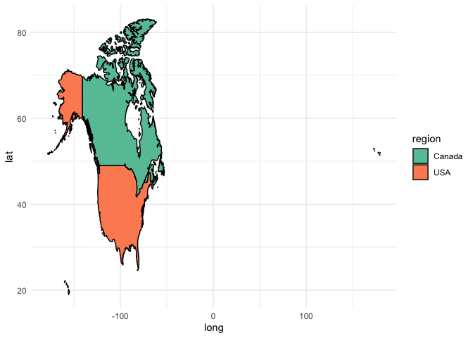

```r
ggplot(northern_america1,aes(x = long,y = lat,group = group,fill = region))+
  geom_polygon(colour="black")+
  scale_fill_brewer(palette = "Set2")+
  theme_minimal()
```

```r
#install.packages("DT")
library(DT)
```

#final app

```r
ui <- dashboardPage(skin = "green",
  dashboardHeader(title = "Bird"),
  dashboardSidebar(
    sidebarMenu(
      menuItem("Home", tabName = "home", icon = icon("home")),
      menuItem("Map",tabName = "map",icon = icon("thumbtack")),
      menuItem("Table",tabName = "table",icon = icon("table")),
      menuItem("Body Mass", tabName = "bodymass", icon = icon("tree")),
      menuItem("Average Body Mass", tabName = "avg", icon = icon("leaf")),
      menuItem("Diet",tabName = "diet",icon = icon("stats", lib = "glyphicon")),
      menuItem("Migration",tabName = "migration",icon = icon("globe"))
    )),
  dashboardBody(
    tags$head(tags$style(HTML('
      .main-header .logo {
        font-family: "Georgia", Times, "Times New Roman", serif;
        font-weight: bold;
        font-size: 24px;
      }
    '))),


      tabItems(
      #home tab
      tabItem(tabName = "home",
              includeMarkdown("app/home.md")),
      #map
      tabItem(tabName = "map",
              plotOutput("region_map")),
      tabItem(tabName = "table",
                dataTableOutput("bird_new")
              ),
      # First tab content
      tabItem(tabName = "bodymass",
        fluidRow(
          box(width=4,
    selectInput("x","select Biological Order",
                choices = c("Accipitriformes","Anseriformes","Apodiformes","Apterygiformes","Bucerotiformes","Caprimulgiformes","Cariamiformes","Casuariiformes","Charadriiformes","Ciconiiformes","Coliiformes","Columbiformes","Coraciiformes","Cuculiformes","Eurypygiformes","Falconiformes","Galliformes","Gaviiformes","Gruiformes","Leptosomiformes","Mesitornithiformes","Musophagiformes","Opisthocomiformes","Otidiformes","Passeriformes","Pelecaniformes","Phaethontiformes","Phoenicopteriformes","Piciformes","Podicipediformes","Procellariiformes","Psittaciformes","Pteroclidiformes","Rheiformes","Sphenisciformes","Strigiformes","Struthioniformes","Suliformes","Tinamiformes","Trogoniformes"),
                selected = "Accipitriformes")),
          box(title="Body Mass of Bird among Biological Orders",width=8,
    plotOutput("plot",width = "600px",height = "500px"),


        )
      )),

      # Second tab content
      tabItem(tabName = "avg",
        fluidRow(
          box(plotOutput("plot1"),width = 12,height = NULL),
        )
      ),
    tabItem(tabName = "diet",
          fluidRow(
            box(width= 4,
                   plotOutput("diet_type",width = "400px",height = "400px")),
            box(width=4,
                   plotOutput("diet_order",width = "400px",height = "400px")),
            box(width=4,
                   plotOutput("diet_order2",width = "400px",height = "400px")))
           ),
    tabItem(tabName = "migration",
            plotOutput("migration_plot"))
    )
  ))


server <- function(input, output,session) {
  output$plot<-renderPlot({
    bird_new %>%
    filter(ioc_order==input$x)%>%
  ggplot(aes_string(x="ioc_order",y="body_mass_value",fill="ioc_order"))+
  geom_boxplot(alpha=0.8)+
  theme_linedraw()+
  theme(axis.title.x = element_text(size = rel(1.5)))+
      labs(x="Biological Order",y="Body Mass",
           title = "Observations of Body Mass by Biological Order")
  })
  output$plot1<-renderPlot({
    avg_bodymass%>%
      ggplot(aes_string(x="ioc_order",y="mean_bodymass",fill="ioc_order"))+
      geom_col()+
      scale_y_log10()+
      coord_flip()+
      theme_linedraw()+
      labs(title = "Observations of Average Body Mass by Biological Order",
           x="Biological Order",
           y="Average Body Mass")
  })
  output$region_map<-renderPlot({
    ggplot(northern_america1,aes(x = long,y = lat,group = group,fill = region))+
  geom_polygon(colour="black")+
  scale_fill_brewer(palette = "Set2")+
  theme_minimal()
  })
  output$diet_type<-renderPlot({
    diet_long%>%
  ggplot(aes(x=population,y=body_mass_value,fill=diet_type))+
  geom_col()+
  facet_wrap(~diet_type,ncol = 4)+
  theme_linedraw()+
  labs(x="Population",y="Body Mass",title = "Observations by Body Mass and Diet Type ")+
  theme(plot.title = element_text(size = 15,face="bold"))
  })
  output$bird_new<-renderDataTable({
    DT::datatable(bird_new,options = list(orderClasses=TRUE))
  })
  output$diet_order<-renderPlot({
    bird_new%>%
  na.exclude()%>%
  rename(Diet_Type=diet_5cat)%>%
  ggplot(aes(x=ioc_order,y=body_mass_value,fill=Diet_Type))+
  geom_col()+
  coord_flip()+
  theme_linedraw()+
  labs(x="Biological Order",y="Body Mass",title="Distributions of Diet Types among Orders")+
  theme(plot.title = element_text(size = 15,face = "bold",hjust = 0.1))
  })
  output$diet_order2<-renderPlot({
    bird_new%>%
  na.exclude()%>%
  rename(Diet_Type=diet_5cat)%>%
  ggplot(aes(x=ioc_order,y=body_mass_value,fill=Diet_Type))+
  geom_col(position = "dodge")+
  coord_flip()+
  theme_linedraw()+
  labs(x="Biological Order",y="Body Mass",title="Distributions of Diet Types among Orders")+
  theme(plot.title = element_text(size = 15,face = "bold",hjust = 0.1))
  })
  output$migration_plot<-renderPlot({
    bird_new%>%
  select(contains("for_strat"),body_mass_value)%>%
  pivot_longer(cols = starts_with("for_strat_"),
               names_to = ("migration_strategy"),
               names_prefix = "for_start_",
               values_to = "population",
               values_drop_na = TRUE)%>%
  ggplot(aes(x=body_mass_value,y=population,fill=migration_strategy))+
  geom_boxplot(alpha=0.3)+
  geom_violin(alpha=0.6)+
  coord_flip()+
  labs(x="Body Mass",y="Population",title="Observation of Body Mass by Migration Strategy")+
  theme_linedraw()
  })
  session$onSessionEnded(stopApp)
}

shinyApp(ui, server)
```

Shiny applications not supported in static R Markdown documents

#create new data set for second topic(using select only)

```r
diet_bodymass<-bird_new%>%
  select(contains("diet"),body_mass_value)%>%
  select(-diet_5cat)
```

#exporting data

```r
write.csv(diet_bodymass, file = "diet_bodymass.csv", row.names = FALSE)
```

#tidy the data into long form

```r
diet_long<-diet_bodymass%>%
  pivot_longer(
               cols = starts_with("diet"),
               names_to = ("diet_type"),
               names_prefix = "diet_",
               values_to = "population",
               values_drop_na = TRUE)
```

#draw graphs using new data

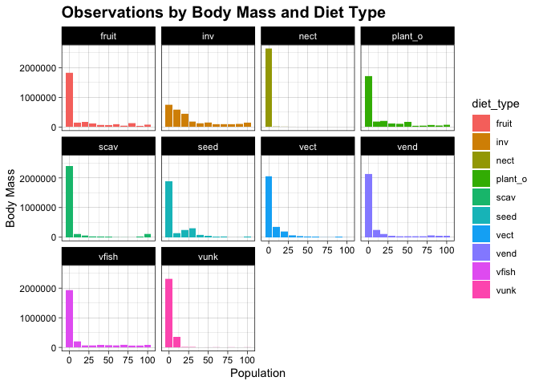

```r
diet_long%>%
  ggplot(aes(x=population,y=body_mass_value,fill=diet_type))+
  geom_col()+
  facet_wrap(~diet_type,ncol = 4)+
  theme_linedraw()+
  labs(x="Population",y="Body Mass",title = "Observations by Body Mass and Diet Type ")+
  theme(plot.title = element_text(size = 15,face="bold"))
```

the reason for that is maybe each order of bird only have a few diet,they don’t eat all the things but just some particular types. so that many zeros exist for each diet type. Maybe relate to their living environment and available sources for them

#rename the data column to make the side panel more clear

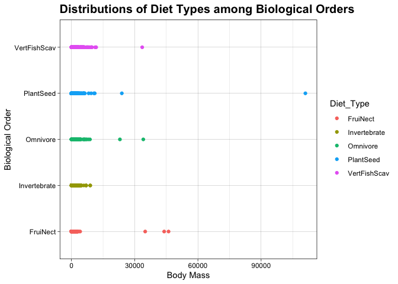

```r
bird_new%>%
  na.exclude()%>%
  rename(Diet_Type=diet_5cat)%>%
  ggplot(aes(x=Diet_Type,y=body_mass_value,color=Diet_Type))+
  geom_point()+
  coord_flip()+
  theme_linedraw()+
  labs(x="Biological Order",y="Body Mass",title="Distributions of Diet Types among Biological Orders")+
  theme(plot.title = element_text(size = 15,face = "bold"))
```

#New graph with position=“dodge” to make the graph representation clear

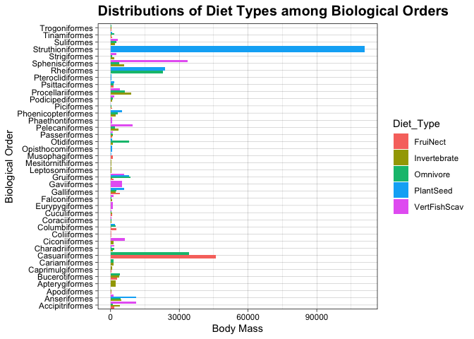

```r
bird_new%>%
  na.exclude()%>%
  rename(Diet_Type=diet_5cat)%>%
  ggplot(aes(x=ioc_order,y=body_mass_value,fill=Diet_Type))+
  geom_col(position = "dodge")+
  coord_flip()+
  theme_linedraw()+
  labs(x="Biological Order",y="Body Mass",title="Distributions of Diet Types among Biological Orders")+
  theme(plot.title = element_text(size = 15,face = "bold"))
```

#try to analyze why there’s so many 0 for population vs. migration graph

```r
bird_strat<-bird_new%>%
  select(contains("for_strat"),body_mass_value)%>%
  pivot_longer(cols = starts_with("for_strat_"),
               names_to = ("migration_strategy"),
               names_prefix = "for_start_",
               values_to = "population",
               values_drop_na = TRUE)
bird_strat
```

```
## # A tibble: 69,951 × 3
##    body_mass_value migration_strategy      population
##              <dbl> <chr>                        <dbl>
##  1          111000 for_strat_watbelowsurf           0
##  2          111000 for_strat_wataroundsurf          0
##  3          111000 for_strat_ground               100
##  4          111000 for_strat_understory             0
##  5          111000 for_strat_midhigh                0
##  6          111000 for_strat_canopy                 0
##  7          111000 for_strat_aerial                 0
##  8           23000 for_strat_watbelowsurf           0
##  9           23000 for_strat_wataroundsurf          0
## 10           23000 for_strat_ground               100
## # … with 69,941 more rows
```

```r
bird_strat%>%
  count(migration_strategy)
```

```
## # A tibble: 7 × 2
##   migration_strategy          n
##   <chr>                   <int>
## 1 for_strat_aerial         9993
## 2 for_strat_canopy         9993
## 3 for_strat_ground         9993
## 4 for_strat_midhigh        9993
## 5 for_strat_understory     9993
## 6 for_strat_wataroundsurf  9993
## 7 for_strat_watbelowsurf   9993
```

#violin graph for population vs body mass filled with migrational strategy to see if larger body mass affect their strategy

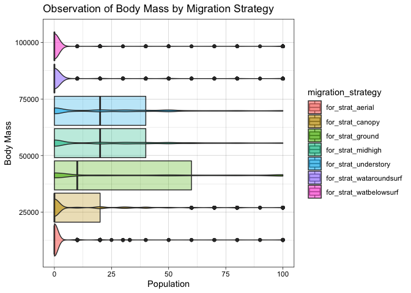

```r
bird_new%>%
  select(contains("for_strat"),body_mass_value)%>%
  pivot_longer(cols = starts_with("for_strat_"),
               names_to = ("migration_strategy"),
               names_prefix = "for_start_",
               values_to = "population",
               values_drop_na = TRUE)%>%
  ggplot(aes(x=body_mass_value,y=population,fill=migration_strategy))+
  geom_boxplot(alpha=0.3)+
  geom_violin(alpha=0.6)+
  coord_flip()+
  labs(x="Body Mass",y="Population",title="Observation of Body Mass by Migration Strategy")+
  theme_linedraw()
```

#which diet types are nocturnal

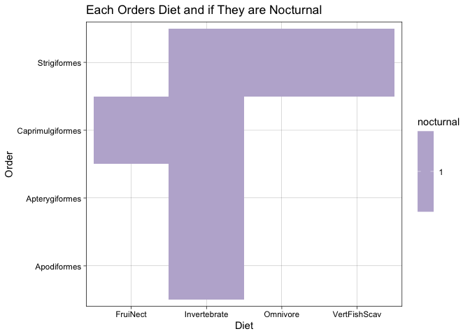

```r
bird_new%>%
  na.exclude()%>%
  filter(nocturnal=="1")%>%
  ggplot(aes(x=ioc_order,y=diet_5cat,fill=nocturnal))+
  geom_tile()+
  scale_fill_gradient(low = "#fbb4ae")+
  geom_path(size=1)+
  theme_linedraw()+
  theme(axis.title.x = element_text(size = rel(1)))+coord_flip()+
  labs(title = 'Each Orders Diet and if They are Nocturnal',
       x="Order", y="Diet")
```

#which diets have which migratory strategies

```r
diet_migration<-bird_new%>%
  select(diet_5cat,contains("for_strat_"))
```

```r
migration_long1<-diet_migration%>%
  pivot_longer(names_to = "Migration",
               names_prefix="for_strat_",
               values_to="Population",
               'for_strat_watbelowsurf':'for_strat_aerial')
```

#Amount of each Migration Strategy for each Diet Type

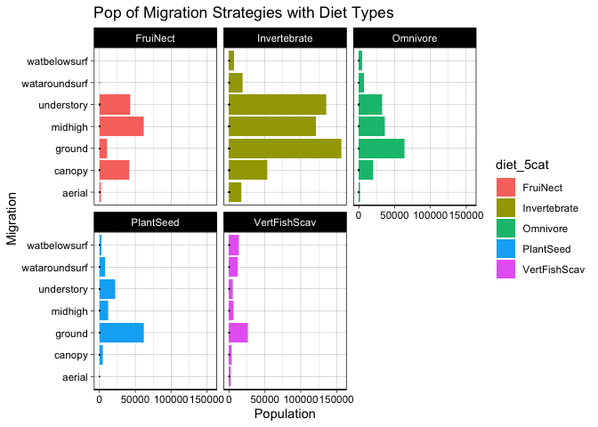

```r
migration_long1%>%
  na.exclude()%>%
  ggplot(aes(x=Population,y=Migration,fill=diet_5cat))+
  geom_col()+
  geom_path()+
  facet_wrap(~diet_5cat)+
  theme_linedraw()+
  theme(axis.line.x = element_line(size = rel(1)))+
    labs(title = "Pop of Migration Strategies with Diet Types",
       y="Migration", x= "Population")
```

#Migration strats for Nocturnal Species

```r
nocturnal_species<-bird_new%>%
  select(ioc_order,nocturnal,contains("for_strat_"))%>%
  filter(nocturnal=="1")
```

```r
nocturnal_species_long<-nocturnal_species%>%
  pivot_longer(names_to = "Migration",
               names_prefix="for_strat_",
               values_to="Population",
               'for_strat_watbelowsurf':'for_strat_aerial')
```

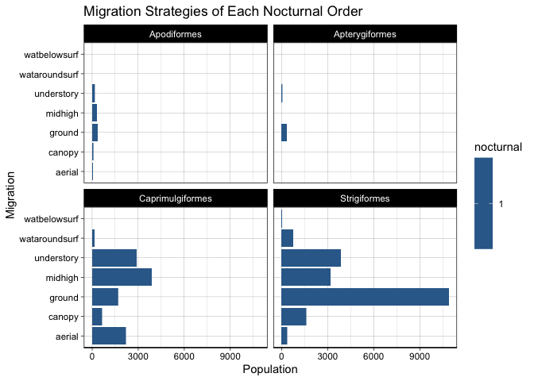

```r
nocturnal_species_long%>%
  ggplot(aes(x=Population,y=Migration,fill=nocturnal))+
  geom_col()+
  facet_wrap(~ioc_order)+
  theme_linedraw()+
  theme(axis.line.x = element_line(size = rel(1)))+
  labs(title = "Migration Strategies of Each Nocturnal Order")
```